# Drinking Water Meta-Analysis Taxa Counts Processing

this notebook takes the viral counts from samtools (or any other program) and does the processing to prepare them for use in taxonomic analyses

# Import Libraries

```r
library(tidyr)
library(readr)
library(dplyr)
library(ggplot2)
library(viridis)
library(vegan)
library(gridExtra)
```

# Import and processing

## import metadata

```r
metadata2 <- read_tsv("updated_processed_all_samples_metadata_20211201.txt", col_names = T)
```

```
There were 17 warnings (use warnings() to see them)
```

## Import viral read counts and coverage info

only counting reads that mapped as part of a pair

import coverage stats from samtools coverage need to remove any lines with NAs (from the lines with the header for each file) “merged_viral_contigs_count.txt” - made evening of 11/13

```r
read_coverage <- read_tsv("merged_viral_contigs_count.txt", col_names = T)
colnames(read_coverage)[ncol(read_coverage)] <- "ReadCounts"
read_coverage$ComboId <- sub("FeatureCounts/", "", read_coverage$ComboId)
read_coverage$ComboId <- sub("_viral_contigs_count.txt", "", read_coverage$ComboId)
read_coverage <- separate(read_coverage, col="Geneid", into=c("contig", "fragment"), sep="\\|\\|viral_frag_", remove=F)
read_coverage <- separate(read_coverage, col="ComboId", into=c("Assembly", "sample"), sep="--", remove=F)
```

```r
read_coverage$sample
```

```
   [1] "mgp80824_B"  "mgp80824_B"  "mgp80824_B"  "mgp80824_B"  "mgp80824_B"  "mgp80824_B"  "mgp80824_B"
   [8] "mgp80824_B"  "mgp80824_B"  "mgp80824_B"  "mgp80824_B"  "mgp80824_B"  "mgp80824_B"  "mgp80824_B"
  [15] "mgp80824_B"  "mgp80824_B"  "mgp80824_B"  "mgp80824_W"  "mgp80824_W"  "mgp80824_W"  "mgp80824_W"
  [22] "mgp80824_W"  "mgp80824_W"  "mgp80824_W"  "mgp80824_W"  "mgp80824_W"  "mgp80824_W"  "mgp80824_W"
  [29] "mgp80824_W"  "mgp80824_W"  "mgp80824_W"  "mgp80824_W"  "mgp80824_W"  "mgp80824_W"  "mgp80824_W"
  [36] "mgp80824_W"  "mgp80824_W"  "mgp80824_W"  "mgp80824_W"  "mgp80824_W"  "mgp80824_W"  "mgp80824_W"
  [43] "mgp80824_W"  "mgp80824_W"  "mgp80824_W"  "mgp80824_WC" "mgp80824_WC" "mgp80824_WC" "mgp80824_WC"
  [50] "mgp80824_WC" "mgp80824_WC" "mgp80824_WC" "mgp80824_WC" "mgp80824_WC" "mgp80824_WC" "mgp80824_WC"
  [57] "mgp80824_WC" "mgp80824_WC" "mgp80824_WC" "mgp80824_WC" "mgs458886"   "mgs458886"   "mgs458886"
  [64] "mgs458886"   "mgs458886"   "mgs458886"   "mgs458886"   "mgs458886"   "mgs458886"   "mgs458886"
  [71] "mgs458886"   "mgs458886"   "mgs458886"   "mgs458886"   "mgs458886"   "mgs458886"   "mgs458886"
  [78] "mgs458886"   "mgs458886"   "mgs458886"   "mgs458886"   "mgs458886"   "mgs458886"   "mgs458886"
  [85] "mgs458886"   "mgs458886"   "mgs458886"   "mgs458886"   "mgs458886"   "mgs458886"   "mgs458886"
  [92] "mgs458886"   "mgs458886"   "mgs458886"   "mgs458886"   "mgs458886"   "mgs458886"   "mgs458886"
  [99] "mgs458886"   "mgs458886"   "mgs458886"   "mgs458886"   "mgs458886"   "mgs458886"   "mgs458886"
```

[output cut: 129 more lines]

# collapse by sample

```r
read_coverage_collapsed <- read_coverage %>%
  select(sample, ReadCounts, Geneid, Length, contig) %>%
  inner_join(metadata2, by=c("sample"="samples")) %>%
  group_by(Geneid, true_samples, Assembly, Length, contig) %>%
  dplyr::summarize(
    total_mapped_reads=sum(ReadCounts)
  )
read_coverage_wide <- read_coverage_collapsed %>%
  pivot_wider(id_cols=c(Geneid, Length),
    names_from=true_samples,
    values_from=total_mapped_reads,
    values_fill=0)
```

| Geneid | true_samples | Assembly | Length | contig | total_mapped_reads |
| --- | --- | --- | --- | --- | --- |
| Aberdeen_Man--Aberdeen_Man_0000001\|\|full\|\|viral_frag_1 | D7_1 | D7 | 272715 | Aberdeen_Man--Aberdeen_Man_0000001\|\|full | 21090 |
| Aberdeen_Man--Aberdeen_Man_0000001\|\|full\|\|viral_frag_1 | D7_2 | D7 | 272715 | Aberdeen_Man--Aberdeen_Man_0000001\|\|full | 57258 |
| Aberdeen_Man--Aberdeen_Man_0000001\|\|full\|\|viral_frag_1 | D7_3 | D7 | 272715 | Aberdeen_Man--Aberdeen_Man_0000001\|\|full | 20100 |
| Aberdeen_Man--Aberdeen_Man_0000001\|\|full\|\|viral_frag_1 | D7_4 | D7 | 272715 | Aberdeen_Man--Aberdeen_Man_0000001\|\|full | 18953 |
| Aberdeen_Man--Aberdeen_Man_0000002\|\|full\|\|viral_frag_1 | D7_1 | D7 | 153870 | Aberdeen_Man--Aberdeen_Man_0000002\|\|full | 7986 |
| Aberdeen_Man--Aberdeen_Man_0000002\|\|full\|\|viral_frag_1 | D7_2 | D7 | 153870 | Aberdeen_Man--Aberdeen_Man_0000002\|\|full | 4656 |

### calculate TPM

TPM = transcripts per kilobase million TPM = (num reads / (geneLength/1000)) / (total RPK for sample / 1000000)

```r
read_counts_norm <- read_coverage_wide[,-c(1,2)]
read_counts_norm <- read_counts_norm/(read_coverage_wide$Length/1000)
sample_counts <- tibble(sample=colnames(read_counts_norm),
                        viral_read_counts=colSums(read_counts_norm))
read_counts_norm <- t(read_counts_norm)
read_counts_norm <- read_counts_norm/(sample_counts$viral_read_counts/1000000)
read_counts_norm <- t(read_counts_norm)

read_counts_norm <- as_tibble(read_counts_norm)
read_counts_norm$Geneid <- read_coverage_wide$Geneid
```

| D7_1 | D7_2 | D7_3 | D7_4 | ND1_1 | ND1_2 | ND1_3 | ND1_4 | ND2_1 | ND2_2 | ND2_3 | mgp80824_B | D3_1 | D3_2 | D4_1 | D4_2 | D4_3 | D4_4 | SRR14143308 | SRR14143319 | SRR14143330 | SRR14143331 | SRR14143299 | SRR14143300 | SRR14143301 | SRR14143296 | SRR14143297 | SRR14143298 | SRR14143329 | SRR14143325 | … |
| --- | --- | --- | --- | --- | --- | --- | --- | --- | --- | --- | --- | --- | --- | --- | --- | --- | --- | --- | --- | --- | --- | --- | --- | --- | --- | --- | --- | --- | --- | --- |
| 2490.136 | 5343.7459 | 2688.6483 | 2468.085 | 0 | 0 | 0 | 0 | 0 | 0 | 0 | 0 | 0 | 0 | 0 | 0 | 0 | 0 | 0 | 0 | 0 | 0 | 0 | 0 | 0 | 0 | 0 | 0 | 0 | 0 | … |
| 1671.209 | 770.1542 | 409.4354 | 1567.598 | 0 | 0 | 0 | 0 | 0 | 0 | 0 | 0 | 0 | 0 | 0 | 0 | 0 | 0 | 0 | 0 | 0 | 0 | 0 | 0 | 0 | 0 | 0 | 0 | 0 | 0 | … |
| 5230.192 | 5665.1282 | 3506.3523 | 5548.726 | 0 | 0 | 0 | 0 | 0 | 0 | 0 | 0 | 0 | 0 | 0 | 0 | 0 | 0 | 0 | 0 | 0 | 0 | 0 | 0 | 0 | 0 | 0 | 0 | 0 | 0 | … |
| 2037.255 | 1484.1255 | 907.9466 | 2349.289 | 0 | 0 | 0 | 0 | 0 | 0 | 0 | 0 | 0 | 0 | 0 | 0 | 0 | 0 | 0 | 0 | 0 | 0 | 0 | 0 | 0 | 0 | 0 | 0 | 0 | 0 | … |
| 3372.020 | 1715.1374 | 1453.9027 | 2610.220 | 0 | 0 | 0 | 0 | 0 | 0 | 0 | 0 | 0 | 0 | 0 | 0 | 0 | 0 | 0 | 0 | 0 | 0 | 0 | 0 | 0 | 0 | 0 | 0 | 0 | 0 | … |
| 5036.638 | 5844.6237 | 3583.6630 | 5528.779 | 0 | 0 | 0 | 0 | 0 | 0 | 0 | 0 | 0 | 0 | 0 | 0 | 0 | 0 | 0 | 0 | 0 | 0 | 0 | 0 | 0 | 0 | 0 | 0 | 0 | 0 | … |

```r
tpm_long <- read_counts_norm  %>%
  pivot_longer(!Geneid, names_to="true_samples", values_to="TPM") %>%
  filter(TPM!=0) %>%
  inner_join(read_coverage_collapsed, by=c("Geneid", "true_samples") )
```

| Geneid | true_samples | TPM | Assembly | Length | contig | total_mapped_reads |
| --- | --- | --- | --- | --- | --- | --- |
| Aberdeen_Man--Aberdeen_Man_0000001\|\|full\|\|viral_frag_1 | D7_1 | 2490.1359 | D7 | 272715 | Aberdeen_Man--Aberdeen_Man_0000001\|\|full | 21090 |
| Aberdeen_Man--Aberdeen_Man_0000001\|\|full\|\|viral_frag_1 | D7_2 | 5343.7459 | D7 | 272715 | Aberdeen_Man--Aberdeen_Man_0000001\|\|full | 57258 |
| Aberdeen_Man--Aberdeen_Man_0000001\|\|full\|\|viral_frag_1 | D7_3 | 2688.6483 | D7 | 272715 | Aberdeen_Man--Aberdeen_Man_0000001\|\|full | 20100 |
| Aberdeen_Man--Aberdeen_Man_0000001\|\|full\|\|viral_frag_1 | D7_4 | 2468.0845 | D7 | 272715 | Aberdeen_Man--Aberdeen_Man_0000001\|\|full | 18953 |
| Aberdeen_Man--Aberdeen_Man_0000002\|\|full\|\|viral_frag_1 | D7_1 | 1671.2093 | D7 | 153870 | Aberdeen_Man--Aberdeen_Man_0000002\|\|full | 7986 |
| Aberdeen_Man--Aberdeen_Man_0000002\|\|full\|\|viral_frag_1 | D7_2 | 770.1542 | D7 | 153870 | Aberdeen_Man--Aberdeen_Man_0000002\|\|full | 4656 |

```r
clusters <- read_tsv("merged_3000_trimmed_viruses_only_20211112_95-85_parsed.tsv", col_names=T)
```

| cluster | contig | length |
| --- | --- | --- |
| Cluster_0 | GX--NODE_1_length_573361_cov_36_347651\|\|full | 573351 |
| Cluster_1 | HN--NODE_2_length_559852_cov_6_764546\|\|full | 559848 |
| Cluster_2 | HB--NODE_2_length_478005_cov_47_875688\|\|full | 477968 |
| Cluster_2 | SRR6797130--NODE_104_length_98403_cov_2_051400\|\|full | 98211 |
| Cluster_2 | SRR6797130--NODE_168_length_69948_cov_4_526485\|\|full | 69947 |
| Cluster_2 | SRR6797130--NODE_194_length_63954_cov_2_800523\|\|full | 63952 |

## collapse clusters

```r
tpm_collapsed <- tpm_long %>%
  inner_join(clusters, by=c("contig", "Length"="length")) %>%
  group_by(cluster, true_samples, Assembly) %>%
  dplyr::summarize(
    total_mapped_reads=sum(total_mapped_reads),
    average_contig_length=mean(Length),
    total_contig_legnth=sum(Length),
    total_tpm=sum(TPM)
  )
```

| cluster | true_samples | Assembly | total_mapped_reads | average_contig_length | total_contig_legnth | total_tpm |
| --- | --- | --- | --- | --- | --- | --- |
| Cluster_1000 | SRR6797132 | SRR6797132 | 3461 | 10456.2 | 52281 | 1059.108931 |
| Cluster_1000 | SRR6986809 | SH | 387 | 6830.0 | 6830 | 201.620682 |
| Cluster_1000 | SRR6986810 | SH | 257 | 6830.0 | 6830 | 64.841620 |
| Cluster_1000 | SRR6986822 | LY | 5524 | 52847.0 | 52847 | 158.757624 |
| Cluster_1000 | SRR6986824 | LY | 3814 | 52847.0 | 52847 | 126.523289 |
| Cluster_1000 | SRR6986825 | SH | 4 | 6830.0 | 6830 | 3.969517 |

## Getting the number of reads per assembly

```r
read_counts <- tpm_collapsed %>%
  inner_join(metadata2, by=c("Assembly")) %>%
  group_by(Assembly) %>%
  dplyr::summarize(
    total_read_count=sum(total_mapped_reads)
  )
```

```r
table(read_counts$total_read_count>=10000)
```

```
FALSE  TRUE
    1    68
```

## Getting number of contigs per assembly

```r
contig_counts <- tibble(Assembly = names(table(tpm_collapsed$Assembly)),
                        Cluster_count = table(tpm_collapsed$Assembly))

contig_counts <- contig_counts %>%
  inner_join(metadata2, by=c("Assembly")) %>%
  filter(!duplicated(Assembly)) %>%
  group_by(Citation) %>%
  dplyr::summarize(
    average_contig_count=mean(Cluster_count)
  )
```

| Citation | average_contig_count |
| --- | --- |
| Chao et al (2013) | 16.0000 |
| Dai et al (2020) | 724.7857 |
| Douterelo et al (2018) | 19.0000 |
| Garner et al (2018) | 412.0000 |
| Huang et al (2014) | 52.0000 |
| Jia et al (2015) | 2784.0000 |
| Ma et al (2017) | 543.2400 |
| Ma et al (2019) | 4864.6667 |
| Pinto et al (2016) | 5094.0000 |
| Potgieter et al (2020) | 4648.0000 |

[output cut: 2 more lines]

# Using a TPM threshold

```r
table(tpm_collapsed$total_tpm>1)
```

```
 FALSE   TRUE
  1086 101485
```

| cluster | true_samples | Assembly | total_mapped_reads | average_contig_length | total_contig_legnth | total_tpm |
| --- | --- | --- | --- | --- | --- | --- |
| Cluster_1000 | SRR6797132 | SRR6797132 | 3461 | 10456.2 | 52281 | 1059.108931 |
| Cluster_1000 | SRR6986809 | SH | 387 | 6830.0 | 6830 | 201.620682 |
| Cluster_1000 | SRR6986810 | SH | 257 | 6830.0 | 6830 | 64.841620 |
| Cluster_1000 | SRR6986822 | LY | 5524 | 52847.0 | 52847 | 158.757624 |
| Cluster_1000 | SRR6986824 | LY | 3814 | 52847.0 | 52847 | 126.523289 |
| Cluster_1000 | SRR6986825 | SH | 4 | 6830.0 | 6830 | 3.969517 |

### Make wide

```r
tpm_wide <- tpm_collapsed_keep %>% pivot_wider(id_cols=cluster,
                                                       names_from=true_samples,
                                                       values_from=total_tpm,
                                                       values_fill=0)
```

```r
tpm_wide <- read_tsv("tpm_wide_contig_clusters.txt")
```

looking at clusters with K07638 annotation

| cluster | ND5_1 | ND5_2 | ND5_3 | ND5_4 | ND3_1 | ND3_2 | ND3_3 | ND3_4 | D9_2 | D9_4 | D7_1 | D7_2 | D7_3 | D7_4 | D1_1 | D1_2 | D1_3 | D1_4 | D3_1 | D3_2 | D4_1 | D4_2 | D4_3 | D4_4 | D6_1 | D6_2 | D6_3 | D8_1 | D8_2 | … |
| --- | --- | --- | --- | --- | --- | --- | --- | --- | --- | --- | --- | --- | --- | --- | --- | --- | --- | --- | --- | --- | --- | --- | --- | --- | --- | --- | --- | --- | --- | --- |
| Cluster_10102 | 0 | 0 | 0 | 0 | 0 | 0 | 0 | 0 | 0 | 0 | 0 | 0 | 0 | 0 | 112.507110 | 21367.345 | 70262.9195 | 41309.47063 | 17048.16 | 6477.263 | 15581.84 | 1906.4697 | 5360.800 | 28064.009 | 105327.66 | 100768.83 | 149066.08 | 10886.162 | 4525.435 | … |
| Cluster_105 | 0 | 0 | 0 | 0 | 0 | 0 | 0 | 0 | 0 | 0 | 0 | 0 | 0 | 0 | 0.000000 | 0.000 | 0.0000 | 0.00000 | 0.00 | 0.000 | 0.00 | 0.0000 | 0.000 | 0.000 | 0.00 | 0.00 | 0.00 | 0.000 | 0.000 | … |
| Cluster_1195 | 0 | 0 | 0 | 0 | 0 | 0 | 0 | 0 | 0 | 0 | 0 | 0 | 0 | 0 | 0.000000 | 0.000 | 0.0000 | 0.00000 | 0.00 | 0.000 | 0.00 | 0.0000 | 0.000 | 0.000 | 0.00 | 0.00 | 0.00 | 0.000 | 0.000 | … |
| Cluster_1547 | 0 | 0 | 0 | 0 | 0 | 0 | 0 | 0 | 0 | 0 | 0 | 0 | 0 | 0 | 0.000000 | 17241.279 | 854.7615 | 33.75621 | 0.00 | 0.000 | 0.00 | 0.0000 | 0.000 | 0.000 | 0.00 | 0.00 | 0.00 | 0.000 | 0.000 | … |
| Cluster_3002 | 0 | 0 | 0 | 0 | 0 | 0 | 0 | 0 | 0 | 0 | 0 | 0 | 0 | 0 | 0.000000 | 0.000 | 0.0000 | 0.00000 | 0.00 | 0.000 | 0.00 | 0.0000 | 0.000 | 0.000 | 0.00 | 0.00 | 0.00 | 0.000 | 0.000 | … |
| Cluster_312 | 0 | 0 | 0 | 0 | 0 | 0 | 0 | 0 | 0 | 0 | 0 | 0 | 0 | 0 | 0.000000 | 0.000 | 0.0000 | 0.00000 | 0.00 | 0.000 | 0.00 | 0.0000 | 0.000 | 0.000 | 0.00 | 0.00 | 0.00 | 0.000 | 0.000 | … |
| Cluster_5267 | 0 | 0 | 0 | 0 | 0 | 0 | 0 | 0 | 0 | 0 | 0 | 0 | 0 | 0 | 9.883106 | 2469.004 | 4048.9588 | 20038.17078 | 0.00 | 0.000 | 14995.91 | 625.9835 | 1980.228 | 3159.800 | 21796.59 | 20060.51 | 16944.37 | 6143.828 | 1881.172 | … |
| Cluster_575 | 0 | 0 | 0 | 0 | 0 | 0 | 0 | 0 | 0 | 0 | 0 | 0 | 0 | 0 | 0.000000 | 0.000 | 0.0000 | 0.00000 | 0.00 | 0.000 | 0.00 | 0.0000 | 0.000 | 0.000 | 0.00 | 0.00 | 0.00 | 0.000 | 0.000 | … |
| Cluster_841 | 0 | 0 | 0 | 0 | 0 | 0 | 0 | 0 | 0 | 0 | 0 | 0 | 0 | 0 | 0.000000 | 0.000 | 0.0000 | 0.00000 | 0.00 | 0.000 | 10315.38 | 1504.8341 | 2875.635 | 5991.721 | 199654.93 | 199277.11 | 130005.98 | 18066.911 | 5044.606 | … |
| Cluster_905 | 0 | 0 | 0 | 0 | 0 | 0 | 0 | 0 | 0 | 0 | 0 | 0 | 0 | 0 | 91.223742 | 15877.782 | 42690.1301 | 32733.58733 | 0.00 | 0.000 | 0.00 | 0.0000 | 0.000 | 0.000 | 21005.35 | 33798.65 | 278983.86 | 0.000 | 0.000 | … |

| cluster | SRR6797132 | SRR6986809 | SRR6986810 | SRR6986822 | SRR6986824 | SRR6986825 | SRR6986807 | SRR6986812 | ND5_1 | ND5_2 | ND5_3 | ND5_4 | SRR6986813 | SRR6986815 | SRR6986818 | SRR6986817 | SRR6986816 | SRR6797129 | S41_20 | S41_21 | S41_5 | S73_1 | S73_10 | S73_17 | S73_19 | S73_6 | S73_8 | SRR6797131 | SRR6986823 | … |
| --- | --- | --- | --- | --- | --- | --- | --- | --- | --- | --- | --- | --- | --- | --- | --- | --- | --- | --- | --- | --- | --- | --- | --- | --- | --- | --- | --- | --- | --- | --- |
| Cluster_1000 | 1059.109 | 201.6207 | 64.84162 | 158.7576 | 126.5233 | 3.969517 | 0.0000 | 0.0000 | 0.000 | 0.00000 | 0.000 | 0.000 | 0.0000 | 0.000 | 0.0000 | 0.0000 | 0 | 0 | 0 | 0 | 0 | 0 | 0 | 0 | 0 | 0 | 0 | 0 | 0 | … |
| Cluster_10000 | 0.000 | 0.0000 | 0.00000 | 0.0000 | 0.0000 | 0.000000 | 319.5519 | 204.8643 | 0.000 | 0.00000 | 0.000 | 0.000 | 0.0000 | 0.000 | 0.0000 | 0.0000 | 0 | 0 | 0 | 0 | 0 | 0 | 0 | 0 | 0 | 0 | 0 | 0 | 0 | … |
| Cluster_10001 | 0.000 | 0.0000 | 0.00000 | 0.0000 | 0.0000 | 0.000000 | 0.0000 | 0.0000 | 2210.183 | 18.01048 | 3407.524 | 161.632 | 0.0000 | 0.000 | 0.0000 | 0.0000 | 0 | 0 | 0 | 0 | 0 | 0 | 0 | 0 | 0 | 0 | 0 | 0 | 0 | … |
| Cluster_10002 | 0.000 | 0.0000 | 0.00000 | 0.0000 | 0.0000 | 0.000000 | 0.0000 | 0.0000 | 0.000 | 0.00000 | 0.000 | 0.000 | 144.5936 | 0.000 | 0.0000 | 0.0000 | 0 | 0 | 0 | 0 | 0 | 0 | 0 | 0 | 0 | 0 | 0 | 0 | 0 | … |
| Cluster_10003 | 0.000 | 0.0000 | 0.00000 | 0.0000 | 0.0000 | 0.000000 | 0.0000 | 0.0000 | 0.000 | 0.00000 | 0.000 | 0.000 | 0.0000 | 1084.824 | 568.4566 | 0.0000 | 0 | 0 | 0 | 0 | 0 | 0 | 0 | 0 | 0 | 0 | 0 | 0 | 0 | … |
| Cluster_10004 | 0.000 | 0.0000 | 0.00000 | 0.0000 | 0.0000 | 0.000000 | 0.0000 | 0.0000 | 0.000 | 0.00000 | 0.000 | 0.000 | 0.0000 | 0.000 | 0.0000 | 303.1184 | 0 | 0 | 0 | 0 | 0 | 0 | 0 | 0 | 0 | 0 | 0 | 0 | 0 | … |

```r
tpm_wide_order <- tpm_wide[order(rowSums(tpm_wide[,-1]), decreasing=T),-1]
```

## format for beta diversity

```r
abund_table <- t(tpm_wide[,-1])
```

```
There were 17 warnings (use warnings() to see them)
```

## Bind metadata and abund_table

| Cluster_1000 | Cluster_10000 | Cluster_10001 | Cluster_10002 | Cluster_10003 | Cluster_10004 | Cluster_10005 | Cluster_10006 | Cluster_10007 | Cluster_10008 | Cluster_10009 | Cluster_1001 | Cluster_10013 | Cluster_10014 | Cluster_10015 | Cluster_10016 | Cluster_10017 | Cluster_10018 | Cluster_10019 | Cluster_1002 | Cluster_10020 | Cluster_10021 | Cluster_10022 | Cluster_10023 | Cluster_10024 | Cluster_10025 | Cluster_10026 | Cluster_10027 | Cluster_10028 | Cluster_10029 |
| --- | --- | --- | --- | --- | --- | --- | --- | --- | --- | --- | --- | --- | --- | --- | --- | --- | --- | --- | --- | --- | --- | --- | --- | --- | --- | --- | --- | --- | --- |
| 1059.108931 | 0.0000 | 0.00000 | 0.0000 | 0.0000 | 0.0000 | 0.0000 | 0.0000 | 0.00000 | 0.00000 | 0 | 0.0000 | 0.0000 | 0 | 0.0000 | 0.00000 | 0.000 | 0 | 0 | 0 | 0.00000 | 0.000000 | 0.000 | 0 | 0 | 0 | 0.000 | 0.00000 | 0.0000 | 0.0000 |
| 201.620682 | 0.0000 | 0.00000 | 0.0000 | 0.0000 | 0.0000 | 0.0000 | 0.0000 | 0.00000 | 0.00000 | 0 | 0.0000 | 0.0000 | 0 | 0.0000 | 13.57696 | 0.000 | 0 | 0 | 0 | 0.00000 | 0.000000 | 0.000 | 0 | 0 | 0 | 0.000 | 26.02172 | 0.0000 | 0.0000 |
| 64.841620 | 0.0000 | 0.00000 | 0.0000 | 0.0000 | 0.0000 | 0.0000 | 0.0000 | 0.00000 | 0.00000 | 0 | 0.0000 | 0.0000 | 0 | 0.0000 | 835.73089 | 0.000 | 0 | 0 | 0 | 0.00000 | 0.000000 | 0.000 | 0 | 0 | 0 | 0.000 | 283.68702 | 0.0000 | 0.0000 |
| 158.757624 | 0.0000 | 0.00000 | 0.0000 | 0.0000 | 0.0000 | 0.0000 | 0.0000 | 0.00000 | 0.00000 | 0 | 0.0000 | 0.0000 | 0 | 0.0000 | 0.00000 | 0.000 | 0 | 0 | 0 | 0.00000 | 0.000000 | 0.000 | 0 | 0 | 0 | 0.000 | 0.00000 | 157.0153 | 0.0000 |
| 126.523289 | 0.0000 | 0.00000 | 0.0000 | 0.0000 | 0.0000 | 0.0000 | 0.0000 | 0.00000 | 0.00000 | 0 | 0.0000 | 0.0000 | 0 | 0.0000 | 0.00000 | 0.000 | 0 | 0 | 0 | 0.00000 | 0.000000 | 0.000 | 0 | 0 | 0 | 0.000 | 0.00000 | 132.5094 | 0.0000 |
| 3.969517 | 0.0000 | 0.00000 | 0.0000 | 0.0000 | 0.0000 | 0.0000 | 0.0000 | 0.00000 | 0.00000 | 0 | 0.0000 | 0.0000 | 0 | 0.0000 | 17.05768 | 0.000 | 0 | 0 | 0 | 0.00000 | 0.000000 | 0.000 | 0 | 0 | 0 | 0.000 | 73.77361 | 0.0000 | 0.0000 |
| 0.000000 | 319.5519 | 0.00000 | 0.0000 | 0.0000 | 0.0000 | 0.0000 | 0.0000 | 0.00000 | 0.00000 | 0 | 204.2619 | 0.0000 | 0 | 0.0000 | 0.00000 | 0.000 | 0 | 0 | 0 | 0.00000 | 0.000000 | 0.000 | 0 | 0 | 0 | 0.000 | 0.00000 | 0.0000 | 0.0000 |
| 0.000000 | 204.8643 | 0.00000 | 0.0000 | 0.0000 | 0.0000 | 0.0000 | 0.0000 | 0.00000 | 0.00000 | 0 | 289.2397 | 0.0000 | 0 | 0.0000 | 0.00000 | 0.000 | 0 | 0 | 0 | 0.00000 | 0.000000 | 0.000 | 0 | 0 | 0 | 0.000 | 0.00000 | 0.0000 | 0.0000 |
| 0.000000 | 0.0000 | 2210.18293 | 0.0000 | 0.0000 | 0.0000 | 0.0000 | 0.0000 | 0.00000 | 0.00000 | 0 | 0.0000 | 0.0000 | 0 | 0.0000 | 0.00000 | 2485.525 | 0 | 0 | 0 | 0.00000 | 0.000000 | 26614.877 | 0 | 0 | 0 | 0.000 | 0.00000 | 0.0000 | 0.0000 |
| 0.000000 | 0.0000 | 18.01048 | 0.0000 | 0.0000 | 0.0000 | 0.0000 | 0.0000 | 0.00000 | 0.00000 | 0 | 0.0000 | 0.0000 | 0 | 0.0000 | 0.00000 | 13676.258 | 0 | 0 | 0 | 0.00000 | 0.000000 | 1100.691 | 0 | 0 | 0 | 0.000 | 0.00000 | 0.0000 | 0.0000 |

[output cut: 20 more lines]

# With Merged Read Counts

### Viral Mapping Read Counts

```r
read_counts_downsampled <- read_tsv("merged_trimmed_viruses_downsampled_10000.txt", col_names = F)
```

```r
head(read_counts_downsampled)
```

[output not shown]

## Process

### Split second column

```r
colnames(read_counts_downsampled)[1] <- "ComboId"
read_counts_downsampled <- separate(read_counts_downsampled, col="X2", into=c("ReadCounts", "UniqContig"), sep=" ")
read_counts_downsampled <- separate(read_counts_downsampled, col="ComboId",
                                    into=c("Assembly", "sample"),
                                    sep="--", remove=F)
read_counts_downsampled$ReadCounts <- as.numeric(read_counts_downsampled$ReadCounts)
```

### Make wide

```r
read_counts_wide <- read_counts_downsampled %>%
  pivot_wider(id_cols=c(UniqContig),
    names_from=sample,
    values_from=ReadCounts,
    values_fill=0)
```

```r
head(read_counts_wide)
```

| UniqContig | mgp80824_B | mgp80824_W | mgp80824_WC | mgs458886 | mgs458889 | S41_17 | S41_18 | S41_19 | S41_20 | S41_21 | S41_4 | S41_5 | S41_6 | S73_1 | S73_10 | S73_17 | S73_18 | S73_19 | S73_20 | S73_5 | S73_6 | S73_7 | S73_8 | SRR14143296 | SRR14143297 | SRR14143298 | SRR14143299 | SRR14143300 | SRR14143301 | … |
| --- | --- | --- | --- | --- | --- | --- | --- | --- | --- | --- | --- | --- | --- | --- | --- | --- | --- | --- | --- | --- | --- | --- | --- | --- | --- | --- | --- | --- | --- | --- |
| B--NODE_271_length_8495_cov_4_377762\|\|full | 4 | 0 | 0 | 0 | 0 | 0 | 0 | 0 | 0 | 0 | 0 | 0 | 0 | 0 | 0 | 0 | 0 | 0 | 0 | 0 | 0 | 0 | 0 | 0 | 0 | 0 | 0 | 0 | 0 | … |
| B--NODE_273_length_8441_cov_6_756098 | 16 | 0 | 0 | 0 | 0 | 0 | 0 | 0 | 0 | 0 | 0 | 0 | 0 | 0 | 0 | 0 | 0 | 0 | 0 | 0 | 0 | 0 | 0 | 0 | 0 | 0 | 0 | 0 | 0 | … |
| B--NODE_325_length_7306_cov_660_423295\|\|full | 24 | 0 | 0 | 0 | 0 | 0 | 0 | 0 | 0 | 0 | 0 | 0 | 0 | 0 | 0 | 0 | 0 | 0 | 0 | 0 | 0 | 0 | 0 | 0 | 0 | 0 | 0 | 0 | 0 | … |
| B--NODE_329_length_7279_cov_4_870175 | 8 | 0 | 0 | 0 | 0 | 0 | 0 | 0 | 0 | 0 | 0 | 0 | 0 | 0 | 0 | 0 | 0 | 0 | 0 | 0 | 0 | 0 | 0 | 0 | 0 | 0 | 0 | 0 | 0 | … |
| B--NODE_474_length_5565_cov_4_294643\|\|full | 2 | 0 | 0 | 0 | 0 | 0 | 0 | 0 | 0 | 0 | 0 | 0 | 0 | 0 | 0 | 0 | 0 | 0 | 0 | 0 | 0 | 0 | 0 | 0 | 0 | 0 | 0 | 0 | 0 | … |
| B--NODE_513_length_5230_cov_12_635164\|\|full | 18 | 0 | 0 | 0 | 0 | 0 | 0 | 0 | 0 | 0 | 0 | 0 | 0 | 0 | 0 | 0 | 0 | 0 | 0 | 0 | 0 | 0 | 0 | 0 | 0 | 0 | 0 | 0 | 0 | … |

```r
range(colSums(read_counts_wide[,-1]))
```

```
[1]    1 9999
```

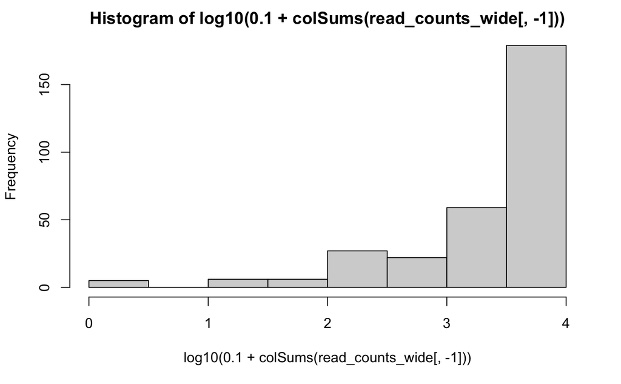

```r
hist(log10(0.1+colSums(read_counts_wide[,-1])))
```

```r
table(colSums(read_counts_wide[,-1])==10000)
```

```
FALSE
  304
```

## Processing

### Transpose the matrix to have samples as rows

```r
abund_table<-t(read_counts_wide[,-1])
```

Turn the abund_table matrix into a tibble.

```r
rn <- rownames(abund_table)
abund_table <- as_tibble(abund_table)
abund_table$samples <- rn
```

## import metadata

(replace with updated metadata file once you have the latitudes added)

```r
metadata2 <- read_tsv("../PaperDrafts/IntermediaryDataForScripts/updated_processed_all_samples_metadata_20210908.txt")
```

## Bind metadata and abund_table

```r
merged <- left_join(abund_table, metadata2, by = c("samples"))
merged$samples[is.na(merged$samples)] <- 1

merged$total_reads <- as.numeric(merged$total_reads)
```

## collapse replicates from Dot’s study

“%>%” allows you to “pipe” different functions. For instance this, loads the “merged” dataframe, then processes it to collapse sequencing replicates. In the Dai et al (2020) study, the authors took multiple sequencing replicates for every sample that they took. For the analyses we’ll be doing, we want to collapse these techincal replicates into one sample. We could have also done this before mapping the reads to the contigs.

```r
abund_table <- merged %>%
  group_by(true_samples, Assembly, residual_type_binary,  Disinfectant_Residual,
           `Koppen Zone`, Sample.Collection.Method.Simplified,
           Extraction.Method.Simplified, Citation, Country, Continent) %>%
  summarize(
    across(1:(ncol(merged)-ncol(metadata2)), mean)
  )
```

| true_samples | Assembly | residual_type_binary | Disinfectant_Residual | Koppen Zone | Sample.Collection.Method.Simplified | Extraction.Method.Simplified | Citation | Country | Continent | V1 | V2 | V3 | V4 | V5 | V6 | V7 | V8 | V9 | V10 |
| --- | --- | --- | --- | --- | --- | --- | --- | --- | --- | --- | --- | --- | --- | --- | --- | --- | --- | --- | --- |
| D1_1 | D1 | Residual Disinfectant | Chlorine | Dfb | 0.22micron filter | Maxwell | Dai et al (2020) | United Kingdom | Europe | 0 | 0 | 0 | 0 | 0 | 0 | 0 | 0 | 0 | 0 |
| D1_2 | D1 | Residual Disinfectant | Chlorine | Dfb | 0.22micron filter | Maxwell | Dai et al (2020) | United Kingdom | Europe | 0 | 0 | 0 | 0 | 0 | 0 | 0 | 0 | 0 | 0 |
| D1_3 | D1 | Residual Disinfectant | Chlorine | Dfb | 0.22micron filter | Maxwell | Dai et al (2020) | United Kingdom | Europe | 0 | 0 | 0 | 0 | 0 | 0 | 0 | 0 | 0 | 0 |
| D1_4 | D1 | Residual Disinfectant | Chlorine | Dfb | 0.22micron filter | Maxwell | Dai et al (2020) | United Kingdom | Europe | 0 | 0 | 0 | 0 | 0 | 0 | 0 | 0 | 0 | 0 |
| D2_1 | D2 | Residual Disinfectant | Chlorine | Cfb | 0.22micron filter | Maxwell | Dai et al (2020) | United Kingdom | Europe | 0 | 0 | 0 | 0 | 0 | 0 | 0 | 0 | 0 | 0 |
| D2_2 | D2 | Residual Disinfectant | Chlorine | Cfb | 0.22micron filter | Maxwell | Dai et al (2020) | United Kingdom | Europe | 0 | 0 | 0 | 0 | 0 | 0 | 0 | 0 | 0 | 0 |

Also, transpose the matrix, so that now the viral populations are the columns and the samples are rows This will be important for joining together this read coverage information with the sample metadata.

```r
abund_table_reads <- abund_table[,-c(1:10)]
abund_table_reads <- abund_table_reads[,colSums(abund_table_reads)>11]
#last row is all NAs
abund_table_reads <- abund_table_reads[-nrow(abund_table_reads),]
abund_table <- abund_table[-nrow(abund_table),]
```

# Richness and Evenness

### Calculate alpha diversity

Calculate the Shannon and Simpson diversities (take into account evenness, as well as the number of taxa), as well as the number of taxa (viral populations).

```r
alpha_wide <- abund_table[,1:10]
```

```
There were 24 warnings (use warnings() to see them)
```

```r
alpha_wide$shannon <- vegan::diversity(abund_table_reads, index = "shannon", MARGIN = 1)
alpha_wide$simpson <- vegan::diversity(abund_table_reads, MARGIN = 1, index = "simpson")
alpha_wide$observed <- vegan::specnumber(abund_table_reads, MARGIN = 1)
```

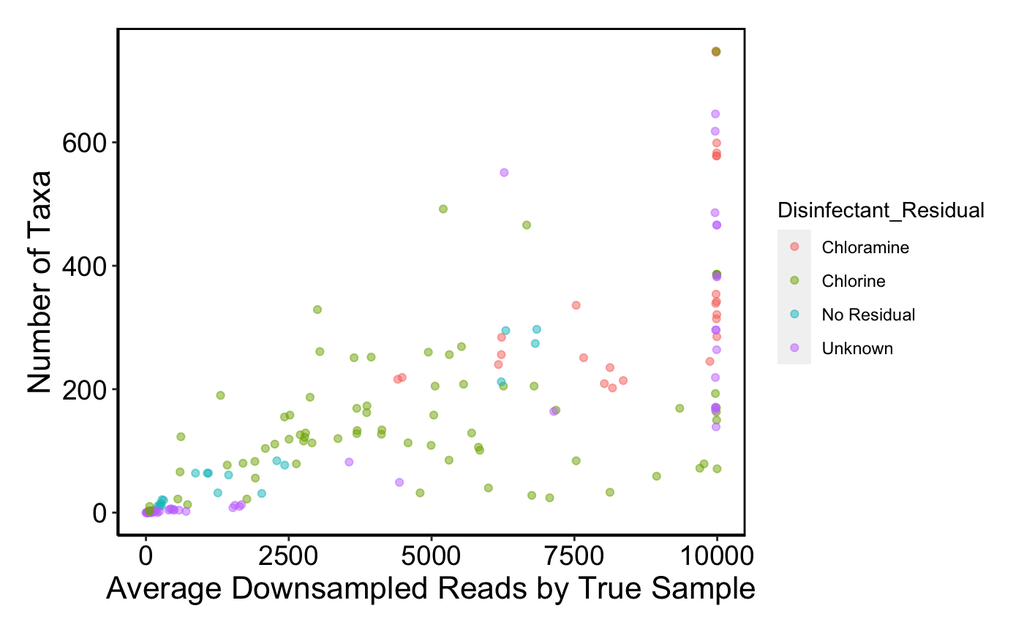

```r
alpha_wide$total_read_counts <- rowSums(abund_table[,-c(1:10)])
ggplot(alpha_all_samples, aes(x=total_read_counts, y=observed,
                        color=Disinfectant_Residual, fill=Disinfectant_Residual)) +
  geom_point(alpha=0.5, shape=21) +
  theme(panel.background = element_blank(),
        axis.line = element_line(colour = "black"),
        panel.border = element_rect(colour = "black", fill=NA, size=1),
        axis.title=element_text(size=16),
        axis.text.y = element_text(size=14, colour = "black"),
        axis.text.x  = element_text(size=14, colour="black"),
        plot.margin = unit(c(1, 1, 1, 1),"lines"),
        legend.position = "right") +
  xlab("Average Downsampled Reads by True Sample") +
  ylab("Number of Taxa")
```

if have many fewer reads, shouldn’t include them. discard, for now, samples with fewer than 5000 reads

```r
alpha_all_samples <- alpha_wide
alpha_wide <- alpha_all_samples[alpha_all_samples$total_read_counts>5000,]

mean(alpha_wide$shannon)
```

```
[1] 4.497605
```

```r
sd(alpha_wide$shannon)
```

```
[1] 1.103407
```

```r
mean(alpha_wide$observed)
```

```
[1] 288.1184
```

```r
sd(alpha_wide$observed)
```

```
[1] 179.5681
```

### visualizing the alpha diversity differences by sample

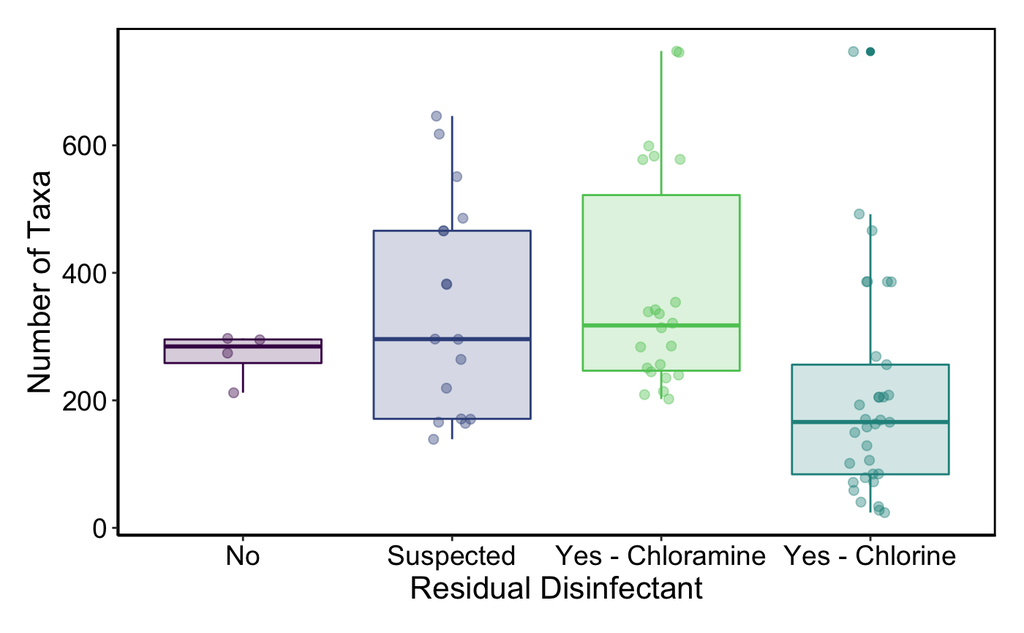

```r
alpha_wide$res <- "Suspected"
#alpha_wide$res[alpha_wide$residual_type_binary=="No Residual Disinfectant"] <- "No"
#alpha_wide$res[alpha_wide$residual_type_binary=="Residual Disinfectant"] <- "Yes"

alpha_wide$res[alpha_wide$Disinfectant_Residual=="Chlorine"] <- "Yes - Chlorine"
alpha_wide$res[alpha_wide$Disinfectant_Residual=="Chloramine"] <- "Yes - Chloramine"
alpha_wide$res[alpha_wide$Disinfectant_Residual=="No Residual"] <- "No"

p3 <- ggplot(alpha_wide, aes(x=res, y=observed,
                   color=res, fill=res)) +
  geom_jitter(width=0.1, size=2, alpha=0.4) +
  geom_boxplot() +
  theme(panel.background = element_blank(),
        axis.line = element_line(colour = "black"),
        panel.border = element_rect(colour = "black", fill=NA, size=1),
        axis.title=element_text(size=16),
        axis.text.y = element_text(size=14, colour = "black"),
        axis.text.x  = element_text(size=14, colour="black"),
        plot.margin = unit(c(1, 1, 1, 1),"lines"),
        legend.position = "none") +
  scale_colour_manual(name = 'residual_type_binary',
                     values = alpha(c(viridis(5)[1],
                                      viridis(5)[2],
                                      viridis(5)[4],
                                      viridis(5)[3]), 1)) +
  scale_fill_manual(name = 'residual_type_binary',
                     values = alpha(c(viridis(5)[1],
                                      viridis(5)[2],
                                      viridis(5)[4],
                                      viridis(5)[3]), 0.2)) +
  xlab("Residual Disinfectant") +
  ylab("Number of Taxa")

p3
```

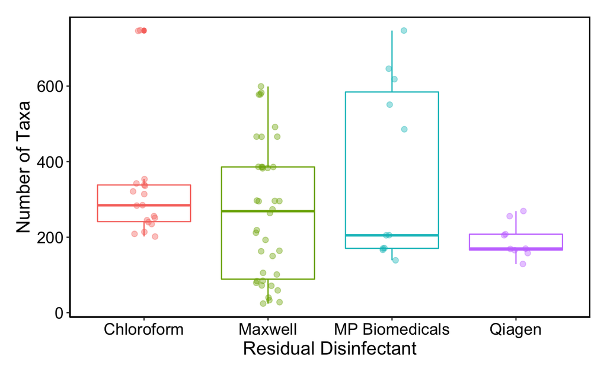

```r
ggplot(alpha_wide, aes(x=Extraction.Method.Simplified, y=observed,
                   color=Extraction.Method.Simplified)) +
  geom_boxplot() +
  geom_jitter(width=0.1, size=2, alpha=0.4) +
  theme(panel.background = element_blank(),
        axis.line = element_line(colour = "black"),
        panel.border = element_rect(colour = "black", fill=NA, size=1),
        axis.title=element_text(size=16),
        axis.text.y = element_text(size=14, colour = "black"),
        axis.text.x  = element_text(size=14, colour="black"),
        plot.margin = unit(c(1, 1, 1, 1),"lines"),
        legend.position = "none") +
  #scale_colour_manual(name = 'residual_type_binary',
  #                   values = alpha(c(viridis(5)[1],
  #                                    viridis(5)[2],
  #                                    viridis(5)[4],
  #                                    viridis(5)[3]), 1)) +
  #scale_fill_manual(name = 'residual_type_binary',
  #                   values = alpha(c(viridis(5)[1],
  #                                    viridis(5)[2],
  #                                    viridis(5)[4],
  #                                    viridis(5)[3]), 0.2)) +
  xlab("Residual Disinfectant") +
  ylab("Number of Taxa")
```

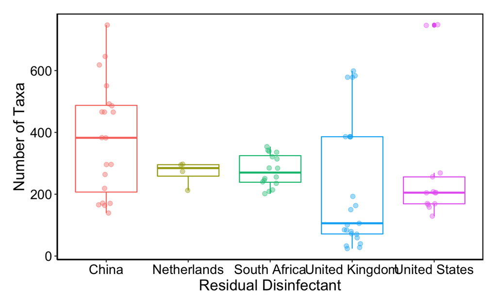

```r
ggplot(alpha_wide, aes(x=Country, y=observed,
                   color=Country)) +
  geom_boxplot() +
  geom_jitter(width=0.1, size=2, alpha=0.4) +
  theme(panel.background = element_blank(),
        axis.line = element_line(colour = "black"),
        panel.border = element_rect(colour = "black", fill=NA, size=1),
        axis.title=element_text(size=16),
        axis.text.y = element_text(size=14, colour = "black"),
        axis.text.x  = element_text(size=14, colour="black"),
        plot.margin = unit(c(1, 1, 1, 1),"lines"),
        legend.position = "none") +
  #scale_colour_manual(name = 'residual_type_binary',
  #                   values = alpha(c(viridis(5)[1],
  #                                    viridis(5)[2],
  #                                    viridis(5)[4],
  #                                    viridis(5)[3]), 1)) +
  #scale_fill_manual(name = 'residual_type_binary',
  #                   values = alpha(c(viridis(5)[1],
  #                                    viridis(5)[2],
  #                                    viridis(5)[4],
  #                                    viridis(5)[3]), 0.2)) +
  xlab("Residual Disinfectant") +
  ylab("Number of Taxa")
```